# Category Classification — Training Pipeline

**Responsibility:** retrieve features from the Hopsworks Feature Store → fit preprocessors → train and evaluate models → save `category_best_model.pkl`.

This notebook implements the **Training** stage of the FTI (Feature-Training-Inference) pipeline. It consumes engineered features produced by the Feature Pipeline (`category_classification_f.ipynb`), trains multiple model architectures (Tier-1 structured-only and Tier-2 structured + text), compares them, and persists the best artifact for the Inference Pipeline (`category_classification_i.ipynb`).

| Input | Description |
| --- | --- |
| Hopsworks Feature Group `category_features` (v1) | Engineered features with split labels |
| `category_metadata.json` | Label maps and feature-column lists produced during feature engineering |

| Output | Description |
| --- | --- |
| `category_best_model.pkl` | Serialised pipeline + preprocessors + metadata + label maps |
| Hopsworks Model Registry `category_classifier` | Versioned model artifact with metrics |

> **Prerequisites:** Feature Pipeline (`category_classification_f.ipynb`) must have run to populate the Feature Store and metadata file. **Next stage:** run `category_classification_i.ipynb` (Inference Pipeline) which loads the saved artifact and scores new batches.

## Shared Imports & Configuration

Import standard-library and third-party packages used across the entire Training Pipeline. This cell also configures global plotting defaults, suppresses warnings for cleaner output, and sets pandas display options so wide DataFrames render correctly in the notebook.

```python
import json
import os
import pickle
import random
import shutil
import warnings
from pathlib import Path

import numpy as np               # Numerical arrays and random-seed control
import pandas as pd              # DataFrames for feature manipulation
import matplotlib.pyplot as plt  # Plotting backend
import seaborn as sns            # Statistical visualisations (heatmaps, bar plots)
import scipy.sparse as sp        # Sparse-matrix checks for TF-IDF output

from IPython.display import display          # Pretty-print DataFrames in notebook cells
from sklearn.compose import ColumnTransformer  # Multi-column preprocessing pipelines
from sklearn.dummy import DummyClassifier      # Baseline model (most-frequent class)
from sklearn.experimental import enable_halving_search_cv  # noqa — enables HalvingRandomSearchCV
from sklearn.feature_extraction.text import TfidfVectorizer  # Text → sparse TF-IDF vectors
from sklearn.linear_model import LogisticRegression          # Linear baseline classifier
from sklearn.metrics import (
    balanced_accuracy_score, classification_report,
    confusion_matrix, f1_score,
)
from sklearn.model_selection import (
    HalvingRandomSearchCV, StratifiedKFold,  # Hyper-parameter search + cross-validation folds
    cross_val_score,                         # Quick CV scoring helper
)
from sklearn.pipeline import Pipeline                     # Chain preprocessing + classifier
from sklearn.preprocessing import OrdinalEncoder, StandardScaler, TargetEncoder

from lightgbm import LGBMClassifier  # Gradient-boosted trees (primary model family)

import hopsworks  # Hopsworks Feature Store and Model Registry client
import tomllib  # Python 3.11+ std-lib TOML parser
from category_classification import (
    make_dist, tfidf_kw,
    TwoStageClassifier, evaluate,
    predict_dispatch,
    fp3_platform_worker,
)
import gc
from matplotlib.patches import Patch
from IPython.display import display, Markdown
from datetime import datetime


# Suppress noisy convergence / deprecation warnings during grid search
warnings.filterwarnings("ignore")
# Global figure defaults for all matplotlib plots generated in this notebook
plt.rcParams.update({"figure.figsize": (14, 6), "figure.dpi": 100, "font.size": 11})
sns.set_style("whitegrid")
pd.set_option("display.max_columns", 50)
print("Imports OK.")
```

```
Imports OK.
```

## TOML Configuration & Distribution Helper

Load the central `category_classification_fti.toml` configuration file. This file defines paths, Hopsworks connection details, feature-engineering parameters, model hyper-parameter search spaces, and reproducibility settings. We also import reusable helpers (`make_dist`, `tfidf_kw`, `TwoStageClassifier`, `evaluate`, `predict_dispatch`, `fp3_platform_worker`) from the shared module `category_classification.py` so they stay in version control rather than inline notebook code.

```python
# Import project-specific helpers from the shared Python module
# (imported in the first cell above)

CFG_PATH = Path("category_classification_fti.toml")
with open(CFG_PATH, "rb") as f:
    cfg = tomllib.load(f)  # Load the full configuration tree into a dict

# LightGBM can run on CPU or GPU depending on environment / config
_LGB_DEVICE = cfg["models"]["lightgbm"].get("device", "cpu")
print(f"Config loaded from {CFG_PATH}")
print(f"LightGBM device: {_LGB_DEVICE}")
```

```
Config loaded from category_classification_fti.toml
LightGBM device: cpu
```

## Path, Constant & Service Definitions

Resolve every file-system path, reproducibility seed, domain constant (e.g. the name of the "OTHER" catch-all category), and Hopsworks Feature Group / Feature View identifier from the loaded TOML config. Centralising these values means the rest of the notebook is declarative: change the TOML and the entire pipeline adapts without touching code.

**Outputs:** `MODEL_ARTIFACT`, `METADATA_PATH`, `RANDOM_STATE`, `HOPSWORKS_HOST`, `FG_NAME`, `FV_NAME`, `MODEL_NAME`, and many more.

```python
# ── Paths ─────────────────────────────────────────────────────────────────────
# Resolve output paths from the TOML [paths] section
_paths = cfg["paths"]
MODEL_ARTIFACT    = Path(_paths["model_artifact"])    # e.g. category_best_model.pkl
MODEL_EXPORT_DIR  = Path(_paths["model_export_dir"])  # Temporary staging for Hopsworks upload
CV_RESULTS_PATH   = Path(_paths["cv_results"])        # Optional CV results cache
PREDICTIONS_PATH  = Path(_paths["predictions"])       # Optional inference-output cache
METADATA_PATH     = Path(_paths["metadata"])          # JSON with label maps & column lists

# ── Reproducibility ────────────────────────────────────────────────────────────
_repr = cfg["reproducibility"]
RANDOM_STATE  = _repr["random_state"]   # Fixed seed for every stochastic operation
N_CV_FOLDS    = _repr["n_cv_folds"]     # Number of stratified CV folds
# Seed NumPy and Python std-lib random so splits, sampling, and LightGBM are deterministic
np.random.seed(RANDOM_STATE)
random.seed(RANDOM_STATE)

# ── Domain constants ───────────────────────────────────────────────────────────
_domain = cfg["domain"]
OTHER_CAT  = _domain["other_category"]  # Human-readable name of the catch-all class
PREFIX     = _domain["prefix"]          # Prefix used for feature naming
TEXT_COL   = _domain["text_col"]        # Primary free-text column
TEXT_COL_2 = _domain["text_col_2"]      # Secondary free-text column
TEXT_COL_3 = _domain["text_col_3"]      # Tertiary free-text column
# High-cardinality columns are target-encoded; low-cardinality ones are ordinal-encoded
HIGH_CARD  = cfg["features"]["categorical"]["encoding"]["high_cardinality"]

# ── Hopsworks ─────────────────────────────────────────────────────────────────
# Read connection params from env vars (preferred for CI/CD) or fall back to TOML
_hw = cfg["hopsworks"]
HOPSWORKS_HOST    = os.environ.get("HOPSWORKS_HOST",    _hw["host"])
HOPSWORKS_PROJECT = os.environ.get("HOPSWORKS_PROJECT", _hw["project"])
HOPSWORKS_API_KEY = os.environ.get("HOPSWORKS_API_KEY", _hw["api_key"])
FG_NAME           = _hw["feature_group"]["name"]
FG_VERSION        = _hw["feature_group"]["version"]
# Text feature groups store large text fields separately to avoid bloating the struct FG
FG_TEXT_1_NAME    = _hw.get("feature_group_text_1", {}).get("name",    FG_NAME + "_text_1")
FG_TEXT_1_VERSION = _hw.get("feature_group_text_1", {}).get("version", 1)
FG_TEXT_2_NAME    = _hw.get("feature_group_text_2", {}).get("name",    FG_NAME + "_text_2")
FG_TEXT_2_VERSION = _hw.get("feature_group_text_2", {}).get("version", 1)
FG_TEXT_3_NAME    = _hw.get("feature_group_text_3", {}).get("name",    FG_NAME + "_text_3")
FG_TEXT_3_VERSION = _hw.get("feature_group_text_3", {}).get("version", 1)
FV_NAME           = _hw.get("feature_view", {}).get("name",    FG_NAME + "_view")
FV_VERSION        = _hw.get("feature_view", {}).get("version", 1)
MODEL_NAME        = _hw["model_registry"]["name"]


print(f"Metadata  : {METADATA_PATH}")
print(f"Model     : {MODEL_ARTIFACT}")
print(f"Hopsworks : {HOPSWORKS_HOST}  project={HOPSWORKS_PROJECT}")
print(f"  FG (struct) : {FG_NAME} v{FG_VERSION}")
print(f"  FG (text 1) : {FG_TEXT_1_NAME} v{FG_TEXT_1_VERSION}")
print(f"  FG (text 2) : {FG_TEXT_2_NAME} v{FG_TEXT_2_VERSION}")
print(f"  FG (text 3) : {FG_TEXT_3_NAME} v{FG_TEXT_3_VERSION}")
print(f"  FV          : {FV_NAME} v{FV_VERSION}")
print(f"  Model       : {MODEL_NAME}")
```

```
Metadata  : category_metadata.json
Model     : category_best_model.pkl
Hopsworks : eu-west.cloud.hopsworks.ai  project=project_mlops_57321
  FG (struct) : category_features v1
  FG (text 1) : category_features_text_1 v1
  FG (text 2) : category_features_text_2 v1
  FG (text 3) : category_features_text_3 v1
  FV          : category_features_view v1
  Model       : category_classifier
```

# Part 2 — Training Pipeline

**Responsibility:** retrieve features from the Hopsworks Feature Store → fit preprocessors → train and evaluate models → save `category_best_model.pkl`.

This is the main training body. You can re-run from this point after tweaking model architecture, hyper-parameters, or evaluation logic without re-executing the Feature Pipeline (provided the Feature Store and metadata file are still intact).

**Inputs:**

- Hopsworks Feature Group `category_features` (v1) and the three text satellite FGs
- `category_metadata.json` (label maps, column lists, split configuration)

**Outputs:**

- `category_best_model.pkl` — serialised scikit-learn Pipeline + preprocessors + metadata
- Hopsworks Model Registry entry — versioned artifact with attached metrics

## TP-1 · Load Features from Hopsworks Feature Store

Connect to Hopsworks, materialise the Feature View, and build chronological train/test splits that mirror the split logic used in the Feature Pipeline (FP-3). This cell also recomputes platform-level rolling statistics **on the training split only** to prevent data leakage, drops classes with too few samples for stratified CV, and constructs:

- `X_tr` / `X_te` — Tier-1 structured-feature matrices
- `X_tr_t2` / `X_te_t2` — Tier-2 matrices (structured + the three text columns)
- `y_tr` / `y_te` — integer-encoded category labels

```python
if not METADATA_PATH.exists():
    raise FileNotFoundError(f"{METADATA_PATH} not found — run _f notebook first.")

# Load metadata produced by the Feature Pipeline (label maps, column lists, FG versions)
with open(METADATA_PATH) as f:
    meta = json.load(f)

# Unpack metadata into notebook-level variables so downstream cells stay clean
target_labels        = meta["target_labels"]
label_map            = meta["label_map"]
label_map_inv        = {int(k): v for k, v in meta["label_map_inv"].items()}
other_idx            = meta["other_idx"]
n_classes            = meta["n_classes"]
short_other          = meta["short_other"]
FEATURE_COLS         = meta["FEATURE_COLS"]
CATEGORICAL_FEATURES = meta["CATEGORICAL_FEATURES"]
NUMERICAL_FEATURES   = meta["NUMERICAL_FEATURES"]
HIGH_CARD            = meta["HIGH_CARD"]
LOW_CARD             = meta["LOW_CARD"]
TEXT_COL             = meta["TEXT_COL"]
TEXT_COL_2           = meta.get("TEXT_COL_2", "incompatible_content_explanation")
TEXT_COL_3           = meta.get("TEXT_COL_3", "decision_facts")
# Keep FG/FV names from metadata, falling back to TOML-derived constants if absent
_fg_name             = meta["fg_name"]
_fg_version          = meta["fg_version"]
_fg_text_1_name      = meta.get("fg_text_1_name",    FG_TEXT_1_NAME)
_fg_text_1_version   = meta.get("fg_text_1_version", FG_TEXT_1_VERSION)
_fg_text_2_name      = meta.get("fg_text_2_name",    FG_TEXT_2_NAME)
_fg_text_2_version   = meta.get("fg_text_2_version", FG_TEXT_2_VERSION)
_fg_text_3_name      = meta.get("fg_text_3_name",    FG_TEXT_3_NAME)
_fg_text_3_version   = meta.get("fg_text_3_version", FG_TEXT_3_VERSION)
_fv_name             = meta.get("fv_name",    FV_NAME)
_fv_version          = meta.get("fv_version", FV_VERSION)
_fp                  = cfg["feature_pipeline"]

# ── Functions for extraction steps ────────────────────────────────────────────

def _ensure_target_enc(df_all, fg_struct):
    """Fetch target_enc from the struct FG when Hopsworks batch data omits it.

    Mutates *df_all* by left-merging on ``row_id``.
    """
    print("  target_enc missing from batch data — fetching from struct FG...")
    _target_df = fg_struct.select(["row_id", "target_enc"]).read(dataframe_type="pandas")
    return df_all.merge(_target_df, on="row_id", how="left")


def _drop_unparseable_dates(df_all, _app_ts):
    """Drop rows whose application_date could not be parsed.

    Returns the filtered ``(df_all, _app_ts)``.
    """
    _valid_mask = _app_ts.notna()
    _n_dropped = (~_valid_mask).sum()
    if _n_dropped:
        print(f"  Dropping {_n_dropped} row(s) with unparseable application_date.")
        df_all = df_all[_valid_mask].copy()
        _app_ts = _app_ts[_valid_mask]
    return df_all, _app_ts


def _drop_sparse_classes(X_tr_all, X_te_all, y_tr, y_te,
                         target_labels, label_map, label_map_inv,
                         n_classes, short_other, other_idx):
    """Remove classes with fewer than 2 training samples and remap labels.

    Returns the updated ``(X_tr_all, X_te_all, y_tr, y_te, target_labels,
    label_map, label_map_inv, n_classes, other_idx)``.
    """
    _tr_vc = pd.Series(y_tr).value_counts()
    # Any class with < 2 train samples OR present only in test cannot be stratified
    _too_few = set(_tr_vc[_tr_vc < 2].index) | (set(np.unique(y_te)) - set(_tr_vc.index))
    if not _too_few:
        # Nothing to drop — return the original objects unchanged.
        return (X_tr_all, X_te_all, y_tr, y_te,
                target_labels, label_map, label_map_inv, n_classes, other_idx)
    _drop_names = [label_map_inv[int(c)] for c in sorted(_too_few)]
    print(f"Dropping {len(_too_few)} class(es) with < 2 training samples: {_drop_names}")
    _keep_tr = ~np.isin(y_tr, list(_too_few))
    _keep_te = ~np.isin(y_te, list(_too_few))
    X_tr_all = X_tr_all[_keep_tr].reset_index(drop=True)
    X_te_all = X_te_all[_keep_te].reset_index(drop=True)
    y_tr = y_tr[_keep_tr]
    y_te = y_te[_keep_te]
    # Build a contiguous 0..N-1 mapping so classifiers receive dense labels
    _old_to_new = {old: new for new, old in enumerate(sorted(set(y_tr) | set(y_te)))}
    y_tr = np.array([_old_to_new[v] for v in y_tr], dtype=int)
    y_te = np.array([_old_to_new[v] for v in y_te], dtype=int)
    target_labels = [label_map_inv[int(old)] for old in sorted(_old_to_new.keys())]
    label_map = {lbl: i for i, lbl in enumerate(target_labels)}
    label_map_inv = {i: lbl for lbl, i in label_map.items()}
    n_classes = len(target_labels)
    other_idx = label_map[short_other]
    print(f"  Remapped to {n_classes} classes. OTHER index = {other_idx}")
    return (X_tr_all, X_te_all, y_tr, y_te,
            target_labels, label_map, label_map_inv, n_classes, other_idx)


def _recompute_platform_features(X_tr_all, X_te_all, X_tr, X_te, _fp):
    """Recompute platform rolling features and automation rate on the train split.

    Avoids leakage from the Feature Store's original chronological split.
    Mutates *X_tr* and *X_te* in-place (adds ``platform_volume_3h``,
    ``platform_auto_fraction_3h``, ``platform_content_type_div_3h``,
    ``platform_automation_rate``).

    Returns the ``PLATFORM_AUTOMATION_RATES`` dict for the model artifact.
    """
    PLATFORM_AUTOMATION_RATES = {}
    _ts_col = "created_at" if "created_at" in X_tr_all.columns else "application_date"
    if _ts_col not in X_tr_all.columns:
        print("  WARNING: no timestamp column found — platform rolling features left as-is.")
        return PLATFORM_AUTOMATION_RATES

    # Build auxiliary DataFrames with the platform, timestamp, and automation flag
    _tr_aux = pd.DataFrame({
        "platform_name": X_tr_all["platform_name"].values,
        "_ts": pd.to_datetime(X_tr_all[_ts_col].values, errors="coerce"),
        "_auto": (X_tr_all["automated_detection"].fillna("").str.lower() == "yes").astype(np.float32).values,
        "_ctp": X_tr_all["content_type_primary"].fillna("UNKNOWN").values,
        "_istr": True,
        "_pos": np.arange(len(X_tr_all), dtype=np.int64),
    }, index=X_tr_all.index)
    _te_aux = pd.DataFrame({
        "platform_name": X_te_all["platform_name"].values,
        "_ts": pd.to_datetime(X_te_all[_ts_col].values, errors="coerce"),
        "_auto": (X_te_all["automated_detection"].fillna("").str.lower() == "yes").astype(np.float32).values,
        "_ctp": X_te_all["content_type_primary"].fillna("UNKNOWN").values,
        "_istr": False,
        "_pos": np.arange(len(X_te_all), dtype=np.int64) + len(X_tr_all),
    }, index=X_te_all.index)
    _combo_aux = pd.concat([_tr_aux, _te_aux])
```

```python
    _valid_mask = _combo_aux["_ts"].notna().values
    _n_nat = (~_valid_mask).sum()
    if _n_nat:
        print("  INFO: {} row(s) with unparseable timestamp — using defaults for platform rolling features.".format(_n_nat))

    # Rolling window length in nanoseconds for vectorised time-delta comparisons
    _WIN_NS = np.int64(_fp.get("rolling_window_hours", 3) * 3600 * 1_000_000_000)
    _max_pos = int(_combo_aux["_pos"].max()) + 1
    _vol_buf = np.zeros(_max_pos, dtype=np.float32)
    _af_buf  = np.zeros(_max_pos, dtype=np.float32)
    _div_buf = np.ones(_max_pos, dtype=np.float32)

    # Compute rolling aggregates per platform using the same worker as the Feature Pipeline
    for _plat, _grp in _combo_aux[_valid_mask].groupby("platform_name", sort=False):
        _r = fp3_platform_worker((_plat, _grp), _WIN_NS, "all_prior")
        _tr_p, _vol_tr, _af_tr, _div_tr, _te_p, _vol_te, _af_te, _div_te = _r
        if len(_tr_p):
            _vol_buf[_tr_p] = _vol_tr
            _af_buf[_tr_p]  = _af_tr
            _div_buf[_tr_p] = _div_tr
        if len(_te_p):
            _vol_buf[_te_p] = _vol_te
            _af_buf[_te_p]  = _af_te
            _div_buf[_te_p] = _div_te

    # Write the recomputed buffers back into the Tier-1 DataFrames
    _tr_pos = _tr_aux["_pos"].values
    _te_pos = _te_aux["_pos"].values
    X_tr["platform_volume_3h"]           = _vol_buf[_tr_pos]
    X_tr["platform_auto_fraction_3h"]    = _af_buf[_tr_pos]
    X_tr["platform_content_type_div_3h"] = _div_buf[_tr_pos]
    X_te["platform_volume_3h"]           = _vol_buf[_te_pos]
    X_te["platform_auto_fraction_3h"]    = _af_buf[_te_pos]
    X_te["platform_content_type_div_3h"] = _div_buf[_te_pos]

    # Derive per-platform automation rate from the training split only (no leakage)
    _train_rate = _tr_aux["_auto"].groupby(_tr_aux["platform_name"]).mean()
    PLATFORM_AUTOMATION_RATES = _train_rate.to_dict()
    X_tr["platform_automation_rate"] = X_tr["platform_name"].map(_train_rate).fillna(np.float32(0)).values
    X_te["platform_automation_rate"] = X_te["platform_name"].map(_train_rate).fillna(np.float32(0)).values

    print("  Recomputed platform_volume_3h, platform_auto_fraction_3h, "
          "platform_content_type_div_3h, platform_automation_rate "
          "on training split (automation_rate mean={:.3f})".format(X_tr['platform_automation_rate'].mean()))
    del _tr_aux, _te_aux, _combo_aux, _vol_buf, _af_buf, _div_buf, _train_rate
    return PLATFORM_AUTOMATION_RATES


# ── Connect to Hopsworks ──────────────────────────────────────────────────────
project = hopsworks.login(
    host=HOPSWORKS_HOST,
    project=HOPSWORKS_PROJECT,
    api_key_value=HOPSWORKS_API_KEY,
)
fs = project.get_feature_store()
print(f"Connected  : {HOPSWORKS_HOST}  →  project '{project.name}'")

# ── Get Feature View (recreate if deleted) ────────────────────────────────────
# The Feature View joins the struct FG with the three text FGs on row_id.
try:
    fv = fs.get_feature_view(name=_fv_name, version=_fv_version)
except Exception:
    fv = None
if fv is None:
    fg_struct = fs.get_feature_group(name=_fg_name, version=_fg_version)
    fg_text_1 = fs.get_feature_group(name=_fg_text_1_name, version=_fg_text_1_version)
    fg_text_2 = fs.get_feature_group(name=_fg_text_2_name, version=_fg_text_2_version)
    fg_text_3 = fs.get_feature_group(name=_fg_text_3_name, version=_fg_text_3_version)
    try:
        _fv_query = (
            fg_struct.select_all()
            .join(fg_text_1.select([TEXT_COL]),   on=["row_id"], join_type="left")
            .join(fg_text_2.select([TEXT_COL_2]), on=["row_id"], join_type="left")
            .join(fg_text_3.select([TEXT_COL_3]), on=["row_id"], join_type="left")
        )
    except AttributeError:
        # Fallback for older Hopsworks SDK versions without select_all()
        _struct_cols = [feat.name for feat in fg_struct.features]
        _fv_query = (
            fg_struct.select(_struct_cols)
            .join(fg_text_1.select([TEXT_COL]),   on=["row_id"], join_type="left")
            .join(fg_text_2.select([TEXT_COL_2]), on=["row_id"], join_type="left")
            .join(fg_text_3.select([TEXT_COL_3]), on=["row_id"], join_type="left")
        )
    fv = fs.get_or_create_feature_view(
        name=_fv_name,
        version=_fv_version,
        query=_fv_query,
        description="Category features view for chronological train/test splitting",
    )
    print(f"Feature View '{_fv_name}' v{_fv_version} recreated.")
else:
    print(f"Feature View '{_fv_name}' v{_fv_version} loaded.")
print(f"  Struct FG : '{_fg_name}' v{_fg_version}")
print(f"  Text FG 1 : '{_fg_text_1_name}' v{_fg_text_1_version}")
print(f"  Text FG 2 : '{_fg_text_2_name}' v{_fg_text_2_version}")
print(f"  Text FG 3 : '{_fg_text_3_name}' v{_fg_text_3_version}")

# ── Chronological train/test split (mirrors FP-3) ────────────────────────────
print("Reading all data from Feature View for chronological split...")
df_all = fv.get_batch_data(dataframe_type="pandas")

# Guard: if the target column was dropped by Hopsworks, back-fill it from the struct FG
if "target_enc" not in df_all.columns:
    df_all = _ensure_target_enc(df_all, fg_struct)

# Parse application_date and drop rows that cannot be ordered chronologically
_app_ts = pd.to_datetime(df_all["application_date"], errors="coerce")
df_all, _app_ts = _drop_unparseable_dates(df_all, _app_ts)
_sorted_pos = _app_ts.argsort().values
_n_tr = int(len(_sorted_pos) * (1 - _fp["test_size"]))
_tr_pos = _sorted_pos[:_n_tr]
_te_pos = _sorted_pos[_n_tr:]
X_tr_all = df_all.iloc[_tr_pos].reset_index(drop=True)
X_te_all = df_all.iloc[_te_pos].reset_index(drop=True)
print(f"Chronological split:  Train {len(X_tr_all):,}  Test {len(X_te_all):,}")

# Extract integer-encoded targets before dropping non-feature columns
y_tr = X_tr_all["target_enc"].values.astype(int)
y_te = X_te_all["target_enc"].values.astype(int)

# row_id is only needed for joins; remove it from model inputs
if "row_id" in X_tr_all.columns:
    X_tr_all = X_tr_all.drop(columns=["row_id"])
    X_te_all = X_te_all.drop(columns=["row_id"])
```

```python
# Drop classes with < 2 training samples and re-index labels contiguously
(X_tr_all, X_te_all, y_tr, y_te,
 target_labels, label_map, label_map_inv,
 n_classes, other_idx) = _drop_sparse_classes(
     X_tr_all, X_te_all, y_tr, y_te,
     target_labels, label_map, label_map_inv,
     n_classes, short_other, other_idx,
 )

# Structured-feature DataFrames for Tier-1 models
_missing_num = _fp["missing_numeric"]
X_tr = pd.DataFrame(index=X_tr_all.index)
X_te = pd.DataFrame(index=X_te_all.index)
for c in FEATURE_COLS:
    X_tr[c] = X_tr_all[c].values if c in X_tr_all.columns else _missing_num
    X_te[c] = X_te_all[c].values if c in X_te_all.columns else _missing_num

# ── Recompute platform features on the train split (no leakage) ───────────────
PLATFORM_AUTOMATION_RATES = {}
if all(c in X_tr_all.columns for c in ["platform_name", "automated_detection", "content_type_primary"]):
    PLATFORM_AUTOMATION_RATES = _recompute_platform_features(
        X_tr_all, X_te_all, X_tr, X_te, _fp,
    )
else:
    print("  WARNING: missing platform/aux columns — platform features left as-is.")

# T2 views: structured features + all three text columns side-by-side.
X_tr_t2 = X_tr.copy()
X_te_t2 = X_te.copy()
for col in (TEXT_COL, TEXT_COL_2, TEXT_COL_3):
    X_tr_t2[col] = (X_tr_all[col].fillna("") if col in X_tr_all.columns
                    else pd.Series("", index=X_tr_all.index)).values
    X_te_t2[col] = (X_te_all[col].fillna("") if col in X_te_all.columns
                    else pd.Series("", index=X_te_all.index)).values

# Free the full-feature DataFrames to reduce memory before model training
del X_tr_all, X_te_all, df_all
gc.collect()

print(f"Features loaded — FV '{_fv_name}' v{_fv_version}")
print(f"  Train : {len(X_tr):,}   Test : {len(X_te):,}   Classes : {n_classes}")
print(f"  Structured features ({len(FEATURE_COLS)}): {FEATURE_COLS[:5]} ...")
print(f"  Text columns: {TEXT_COL!r}  {TEXT_COL_2!r}  {TEXT_COL_3!r}")
```

```
2026-05-20 08:45:06,684 INFO: Initializing external client
2026-05-20 08:45:06,685 INFO: Base URL: https://eu-west.cloud.hopsworks.ai:443
```

```
2026-05-20 08:45:07,815 INFO: Python Engine initialized.

Logged in to project, explore it here https://eu-west.cloud.hopsworks.ai:443/p/32025
Connected  : eu-west.cloud.hopsworks.ai  →  project 'project_mlops_57321'
Feature View 'category_features_view' v1 loaded.
  Struct FG : 'category_features' v1
  Text FG 1 : 'category_features_text_1' v1
  Text FG 2 : 'category_features_text_2' v1
  Text FG 3 : 'category_features_text_3' v1
Reading all data from Feature View for chronological split...
Finished: Reading data from Hopsworks, using Hopsworks Feature Query Service (3.63s)
Chronological split:  Train 11,545  Test 2,887
  Recomputed platform_volume_3h, platform_auto_fraction_3h, platform_content_type_div_3h, platform_automation_rate on training split (automation_rate mean=0.841)
Features loaded — FV 'category_features_view' v1
  Train : 11,545   Test : 2,887   Classes : 12
  Structured features (28): ['source_type', 'automated_detection', 'automated_decision', 'platform_name', 'content_language'] ...
  Text columns: 'incompatible_content_ground'  'incompatible_content_explanation'  'decision_facts'
```

## TP-2 · Fit Preprocessors on Training Data

Preprocessors are training artifacts — they must be fit exclusively on training rows to prevent data leakage. We build two ColumnTransformers:

1. **Tier-1 (`preprocessor_t1`)** — ordinal encoding for low-cardinality categoricals, target encoding for high-cardinality categoricals, passthrough for numericals.
2. **Tier-2 (`preprocessor_t2`)** — same as T1 plus three TF-IDF vectorisers for the free-text columns.

Both are stored in `category_best_model.pkl` so the Inference Pipeline can transform raw rows without any connection to the Feature Store.

```python
# ── Tier-1 preprocessor: structured features only ─────────────────────────────
# Read encoder parameters from the TOML config tree
_enc = cfg["features"]["categorical"]["encoding"]
_ord_kw = _enc["ordinal_encoder_params"]
_tgt_kw = _enc["target_encoder_params"]

# ColumnTransformer routes each column list to its designated transformer
preprocessor_t1 = ColumnTransformer([
    ("ord",  OrdinalEncoder(**_ord_kw), LOW_CARD),
    ("tgt",  TargetEncoder(**_tgt_kw),  HIGH_CARD),
    ("num",  "passthrough",             NUMERICAL_FEATURES),
], remainder="drop")
preprocessor_t1.fit(X_tr, y_tr)
print("Tier-1 preprocessor fitted.")

# ── Tier-2 preprocessor: structured + TF-IDF on all three text columns ─────────
_txt = cfg["features"]["text"]
# Issue 11 fix: validate text column fill rates before fitting TF-IDF.
# All-empty text produces a zero-sparse matrix, making Tier-2 a Tier-1 with extra cost.
_txt_min_fill = cfg["features"]["text"].get("min_fill_rate", 0.05)
for _tcol in (TEXT_COL, TEXT_COL_2, TEXT_COL_3):
    _fill = (X_tr_t2[_tcol].fillna("") != "").mean()
    print(f"  {_tcol}: {_fill:.1%} fill rate (train)")
    if _fill < _txt_min_fill:
        raise ValueError(
            f"Text column '{_tcol}' has fill rate {_fill:.1%} < {_txt_min_fill:.0%} in "
            "training data. TF-IDF would train on near-zero signal. "
            "Check that text columns were populated correctly in FP-1."
        )

# tfidf_kw imported from category_classification builds the kwargs dict per column
# ColumnTransformer.fit() internally calls fit_transform(), accumulating all
# sub-transformer outputs simultaneously (~2.8 GB Xs + ~2.8 GB hstack on 2.8 M rows).
# Fix: structural fit on a tiny sample sets sklearn metadata; then each sub-transformer
# is fitted individually (one peak at a time); fitted estimators are injected into
# transformers_ so downstream transform() and Pipeline CV calls work unchanged.
_SAMPLE = cfg["feature_pipeline"].get("preprocessor_fit_sample", 1_000)
preprocessor_t2 = ColumnTransformer([
    ("ord",       OrdinalEncoder(**_ord_kw), LOW_CARD),
    ("tgt",       TargetEncoder(**_tgt_kw),  HIGH_CARD),
    ("num",       "passthrough",             NUMERICAL_FEATURES),
    ("tfidf_icg", TfidfVectorizer(**tfidf_kw(_txt["tfidf_icg"])), TEXT_COL),
    ("tfidf_ice", TfidfVectorizer(**tfidf_kw(_txt["tfidf_ice"])), TEXT_COL_2),
    ("tfidf_df",  TfidfVectorizer(**tfidf_kw(_txt["tfidf_df"])),  TEXT_COL_3),
], remainder="drop")

# (1) Structural fit — sets n_features_in_, feature_names_in_, sparse_output_,
#     _remainder and all other sklearn fitted-state metadata.
preprocessor_t2.fit(X_tr_t2.iloc[:_SAMPLE], y_tr[:_SAMPLE])
gc.collect()

# (2) Fit sub-transformers on full data one at a time to cap peak memory.
_ord_enc   = OrdinalEncoder(**_ord_kw).fit(X_tr_t2[LOW_CARD])
gc.collect()
_tgt_enc   = TargetEncoder(**_tgt_kw).fit(X_tr_t2[HIGH_CARD], y_tr)
gc.collect()
_tfidf_icg = TfidfVectorizer(**tfidf_kw(_txt["tfidf_icg"])).fit(X_tr_t2[TEXT_COL])
gc.collect()
_tfidf_ice = TfidfVectorizer(**tfidf_kw(_txt["tfidf_ice"])).fit(X_tr_t2[TEXT_COL_2])
gc.collect()
_tfidf_df  = TfidfVectorizer(**tfidf_kw(_txt["tfidf_df"])).fit(X_tr_t2[TEXT_COL_3])
gc.collect()

# (3) Inject properly-fitted estimators.
#     Mutate only the estimator slot of each entry; preserve the column spec and
#     the passthrough entry (index 2) exactly as sklearn stored them after the
#     structural fit — avoids "str has no attribute transform" from a raw "passthrough".
_t2_ = list(preprocessor_t2.transformers_)
for i, (name, _, cols) in enumerate(_t2_):
    if name == "ord":
        _t2_[i] = (name, _ord_enc, cols)
    elif name == "tgt":
        _t2_[i] = (name, _tgt_enc, cols)
    elif name == "tfidf_icg":
        _t2_[i] = (name, _tfidf_icg, cols)
    elif name == "tfidf_ice":
        _t2_[i] = (name, _tfidf_ice, cols)
    elif name == "tfidf_df":
        _t2_[i] = (name, _tfidf_df, cols)
    # "num" (passthrough) and any unknown names are left untouched
preprocessor_t2.transformers_ = _t2_
del _t2_
print("Tier-2 preprocessor fitted.")

# (4) Probe shape on 10 rows — avoids materialising the full ~2.8 GB sparse matrix.
_probe = preprocessor_t2.transform(X_tr_t2.iloc[:10])
print(f"  T2 train matrix: ({len(X_tr_t2)}, {_probe.shape[1]})  sparse={sp.issparse(_probe)}")
print(f"  ({_txt['tfidf_icg']['max_features']} ICG + {_txt['tfidf_ice']['max_features']} ICE + {_txt['tfidf_df']['max_features']} DF TF-IDF dims)")
del _probe; gc.collect()
```

```
Tier-1 preprocessor fitted.
  incompatible_content_ground: 99.7% fill rate (train)
  incompatible_content_explanation: 99.7% fill rate (train)
  decision_facts: 100.0% fill rate (train)
Tier-2 preprocessor fitted.
  T2 train matrix: (11545, 6191)  sparse=True
  (5000 ICG + 3000 ICE + 2000 DF TF-IDF dims)
```

```
23
```

## TP-3 · Shared Helpers

Define the global `results` dictionary that accumulates test-set metrics for every model we train, and instantiate a `StratifiedKFold` splitter for all cross-validation runs. The `evaluate()` helper (imported from `category_classification.py`) populates `results` with macro F1, balanced accuracy, and optional CV statistics.

### TP-3.1 · Evaluation Helper

```python
results = {}  # {name: {macro_f1, bal_acc, tier, approach[, cv_f1_mean, cv_f1_std]}}
# Stratified folds keep class proportions identical across splits — essential for
# imbalanced categories where a random split could orphan minority classes.
cv = StratifiedKFold(n_splits=N_CV_FOLDS, shuffle=False)
# evaluate() imported from category_classification — pass results=results at each call site
print("Evaluation helper ready.")
```

```
Evaluation helper ready.
```

## TP-4 · Tier 1 — Structured Features Only

Train and evaluate models that use **only** the structured engineered features (ordinal/target-encoded categoricals + numericals). This tier establishes a performance floor and ceiling before adding expensive text features.

### TP-4.1 · Baselines — Dummy & Logistic Regression

Fit two fast baselines on Tier-1 data:

1. **DummyClassifier** (`most_frequent`) — predicts the majority class every time. Gives the absolute floor for macro F1.
2. **LogisticRegression** — a linear model with L2 regularisation and class weights. Serves as a strong, interpretable baseline before tree-based boosting.

```python
# ── Dummy baseline ────────────────────────────────────────────────────────────
_dummy = cfg["models"]["dummy"]
dummy = DummyClassifier(strategy=_dummy["strategy"], random_state=RANDOM_STATE)
dummy.fit(X_tr, y_tr)
# Cross-validation on training data to gauge variance (Dummy has none, but kept for consistency)
_dummy_cv = cross_val_score(dummy, X_tr, y_tr, cv=cv, scoring="f1_macro", n_jobs=-1)
evaluate("Dummy (most_frequent)", y_te, dummy.predict(X_te),
         tier="0", approach="baseline", results=results, cv_scores=_dummy_cv)

# ── Logistic Regression (flat, Tier 1) ────────────────────────────────────────
_lr = cfg["models"]["logistic_regression"]
lr_pipe = Pipeline([
    ("pre", preprocessor_t1),   # ordinal / target / passthrough
    ("scl", StandardScaler()),  # centre & scale before linear solver
    ("clf", LogisticRegression(
        solver=_lr.get("solver", "saga"),
        max_iter=_lr["max_iter"],
        tol=_lr.get("tol", 1e-3),
        class_weight=_lr["class_weight"],  # up-weight rare categories
        random_state=RANDOM_STATE,
        n_jobs=_lr["n_jobs"],
    )),
])
lr_pipe.fit(X_tr, y_tr)
# Use fewer CV folds for LR because it is slower on high-dimensional encoded data
_lr_cv = cross_val_score(
    lr_pipe, X_tr, y_tr,
    cv=StratifiedKFold(cfg["training"].get("lr_cv_folds", 3), shuffle=False),
    scoring="f1_macro", n_jobs=-1,
)
evaluate("LogisticRegression (T1, flat)", y_te, lr_pipe.predict(X_te),
         tier="1", approach="flat", results=results, cv_scores=_lr_cv)
```

```
  Dummy (most_frequent)                          macro F1=0.0732  bal_acc=0.0833  cv=0.0728±0.0000
  LogisticRegression (T1, flat)                  macro F1=0.3062  bal_acc=0.5461  cv=0.2993±0.0424
```

```
(0.30623147756850083, 0.5460733130125593)
```

### TP-4.2 · LightGBM (Tier 1, flat search)

Run `HalvingRandomSearchCV` over a broad hyper-parameter space for LightGBM using the Tier-1 preprocessor. Halving search is efficient: it evaluates many random candidates on a small subset of data, promotes the best ones, and retrains on progressively larger subsets, yielding a strong configuration in far less wall-time than exhaustive grid search.

```python
# Build the search-space dict from TOML; make_dist turns [low, high] into scipy distributions
_lgb = cfg["models"]["lightgbm"]
lgbm_t1 = Pipeline([
    ("pre", preprocessor_t1),
    ("clf", LGBMClassifier(objective=_lgb["objective"], num_class=n_classes,
                           class_weight=_lgb["class_weight"], random_state=RANDOM_STATE,
                           n_jobs=_lgb["n_jobs"], verbose=_lgb["verbose"],
                           device=_LGB_DEVICE)),
])
param_lgbm = {
    f"clf__{k}": make_dist(v)
    for k, v in _lgb["search_space"].items()
}
# HalvingRandomSearchCV settings: n_candidates initial draws, factor=reduction per iteration
_hs = cfg["training"]["halving_search"]
search_lgbm_t1 = HalvingRandomSearchCV(
    lgbm_t1, param_lgbm, n_candidates=_hs["n_candidates"], factor=_hs["factor"],
    cv=cv, scoring="f1_macro", random_state=RANDOM_STATE, n_jobs=-1, verbose=0,
    return_train_score=True,  # lets us diagnose overfit (train vs CV gap)
)
search_lgbm_t1.fit(X_tr, y_tr)
print(f"LightGBM T1 best CV macro F1: {search_lgbm_t1.best_score_:.4f}")
print(f"Best params: {search_lgbm_t1.best_params_}")
evaluate("LightGBM (T1, flat)", y_te, search_lgbm_t1.predict(X_te), tier="1", approach="flat", results=results)
```

[output not shown]

[output cut: 683 more lines]

[output not shown]

```
LightGBM T1 best CV macro F1: 0.4371
Best params: {'clf__colsample_bytree': 0.7957811041110252, 'clf__learning_rate': 0.36704694361958623, 'clf__max_depth': 9, 'clf__min_child_samples': 8, 'clf__n_estimators': 232, 'clf__num_leaves': 89, 'clf__reg_alpha': 0.09946866493125138, 'clf__reg_lambda': 0.2578828560574516, 'clf__subsample': 0.9…
  LightGBM (T1, flat)                            macro F1=0.5864  bal_acc=0.5784
```

```
(0.586377165868685, 0.5783990347410729)
```

### TP-4.3 · Two-Stage LightGBM (Tier 1)

Train a **Two-Stage** classifier: Stage 1 is a binary model that decides "OTHER vs NOT-OTHER"; Stage 2 is a multi-class model trained only on the non-OTHER subset. This architecture can improve recall on rare categories because the second-stage classifier does not have to compete with the dominant OTHER class for gradient weight.

```python
# Load two-stage hyper-parameters (lighter than the flat-search config)
_ts = cfg["models"]["lightgbm"]["two_stage"]
ts_clf_t1 = TwoStageClassifier(
    stage1=LGBMClassifier(n_estimators=_ts["n_estimators"], learning_rate=_ts["learning_rate"],
                          num_leaves=_ts["num_leaves"], class_weight=_ts["class_weight"],
                          random_state=RANDOM_STATE, n_jobs=_ts["n_jobs"], verbose=_ts["verbose"],
                          device=_LGB_DEVICE),
    stage2=LGBMClassifier(n_estimators=_ts["n_estimators"], learning_rate=_ts["learning_rate"],
                          num_leaves=_ts["num_leaves"], class_weight=_ts["class_weight"],
                          random_state=RANDOM_STATE, n_jobs=_ts["n_jobs"], verbose=_ts["verbose"],
                          device=_LGB_DEVICE),
    other_label=other_idx,  # The label index that represents the catch-all OTHER class
)
ts_pipe_t1 = Pipeline([("pre", preprocessor_t1), ("clf", ts_clf_t1)])
ts_pipe_t1.fit(X_tr, y_tr)
evaluate("LightGBM (T1, two-stage)", y_te, ts_pipe_t1.predict(X_te),
         tier="1", approach="two-stage", results=results)

# Compute Stage-1 binary F1 separately to diagnose the quality of the OTHER filter
X_te_pre_t1 = preprocessor_t1.transform(X_te)
y_te_bin = (y_te != other_idx).astype(int)
s1_f1 = f1_score(y_te_bin, ts_clf_t1.stage1.predict(X_te_pre_t1), average="binary")
print(f"  Stage-1 binary F1 (NOT-OTHER detection): {s1_f1:.4f}")
```

```
  LightGBM (T1, two-stage)                       macro F1=0.5817  bal_acc=0.5678
  Stage-1 binary F1 (NOT-OTHER detection): 0.7901
```

## TP-5 · Tier 2 — Structured Features + TF-IDF on All Three Text Columns

```python
# Re-define param_lgbm locally so this cell can run independently of TP-4.2
param_lgbm = {
    f"clf__{k}": make_dist(v)
    for k, v in cfg["models"]["lightgbm"]["search_space"].items()
}
# Merge fixed LightGBM args from TOML, overriding search-space defaults where needed
_lgb    = cfg["models"]["lightgbm"]
_lgb_ff = cfg["models"]["lightgbm"]["tier_flat_fixed"]
_lgb_fix = {k: v for k, v in _lgb.items() if k not in ("search_space", "two_stage", "tier_flat_fixed")}
_lgb_t2  = {**_lgb_fix,
             "n_estimators": _lgb_ff["n_estimators"],
             "learning_rate": _lgb_ff["learning_rate"],
             "num_leaves": _lgb_ff["num_leaves"],
             "num_class": n_classes, "device": _LGB_DEVICE}
lgbm_t2_flat = Pipeline([
    ("pre", preprocessor_t2),   # structured + TF-IDF on 3 text columns
    ("clf", LGBMClassifier(**_lgb_t2)),
])
_hs = cfg["training"]["halving_search"]
search_lgbm_t2 = HalvingRandomSearchCV(
    lgbm_t2_flat, param_lgbm, n_candidates=_hs["n_candidates"], factor=_hs["factor"],
     cv=StratifiedKFold(N_CV_FOLDS, shuffle=False),
    scoring="f1_macro", random_state=RANDOM_STATE, n_jobs=-1, verbose=0,
)
search_lgbm_t2.fit(X_tr_t2, y_tr)
print(f"LightGBM T2 best CV macro F1: {search_lgbm_t2.best_score_:.4f}")
evaluate("LightGBM (T2, flat)", y_te, search_lgbm_t2.predict(X_te_t2), tier="2", approach="flat", results=results)
```

[output not shown]

[output cut: 683 more lines]

[output not shown]

```
LightGBM T2 best CV macro F1: 0.7536
  LightGBM (T2, flat)                            macro F1=0.9091  bal_acc=0.9128
```

```
(0.9090530860064588, 0.9127590739842003)
```

### TP-5.1 · Two-Stage LightGBM (Tier 2)

Train a two-stage classifier using the Tier-2 preprocessor (structured + TF-IDF on all three text columns). The Stage-1 binary filter is applied to the full T2 feature matrix, and Stage-2 is trained on the non-OTHER subset. We compare Tier-1 vs. Tier-2 macro F1 side-by-side in the next section (TP-6).

```python
# Load two-stage hyper-parameters from TOML (same architecture as Tier 1)
_ts = cfg["models"]["lightgbm"]["two_stage"]
ts_clf_t2 = TwoStageClassifier(
    stage1=LGBMClassifier(n_estimators=_ts["n_estimators"], learning_rate=_ts["learning_rate"],
                          num_leaves=_ts["num_leaves"], class_weight=_ts["class_weight"],
                          random_state=RANDOM_STATE, n_jobs=_ts["n_jobs"], verbose=_ts["verbose"],
                          device=_LGB_DEVICE),
    stage2=LGBMClassifier(n_estimators=_ts["n_estimators"], learning_rate=_ts["learning_rate"],
                          num_leaves=_ts["num_leaves"], class_weight=_ts["class_weight"],
                          random_state=RANDOM_STATE, n_jobs=_ts["n_jobs"], verbose=_ts["verbose"],
                          device=_LGB_DEVICE),
    other_label=other_idx,
)
ts_pipe_t2 = Pipeline([("pre", preprocessor_t2), ("clf", ts_clf_t2)])
ts_pipe_t2.fit(X_tr_t2, y_tr)
evaluate("LightGBM (T2, two-stage)", y_te, ts_pipe_t2.predict(X_te_t2),
         tier="2", approach="two-stage", results=results)
```

```
  LightGBM (T2, two-stage)                       macro F1=0.8998  bal_acc=0.9010
```

```
(0.89975535777157, 0.9010334224495652)
```

## TP-6 · Model Comparison

Aggregate the `results` dict into a sorted DataFrame and visualise every model's macro F1 and balanced accuracy. The bar charts are colour-coded by tier so it is immediately obvious how much Tier-2 text features improve over Tier-1 structured-only and over the Dummy baseline.

```
=== All models — macro F1 (descending) ===
                        model tier  approach  macro_f1  bal_acc
          LightGBM (T2, flat)    2      flat  0.909053 0.912759
     LightGBM (T2, two-stage)    2 two-stage  0.899755 0.901033
          LightGBM (T1, flat)    1      flat  0.586377 0.578399
     LightGBM (T1, two-stage)    1 two-stage  0.581743 0.567791
LogisticRegression (T1, flat)    1      flat  0.306231 0.546073
        Dummy (most_frequent)    0  baseline  0.073200 0.083333
```

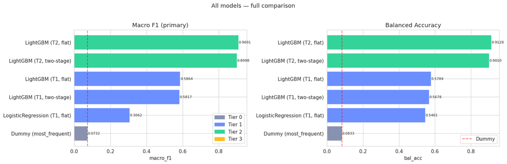

```python
# Assemble results into a DataFrame for sorting and plotting
df_all = pd.DataFrame(results).T.reset_index().rename(columns={"index": "model"})
df_all["macro_f1"] = df_all["macro_f1"].astype(float)
df_all["bal_acc"]  = df_all["bal_acc"].astype(float)
df_all = df_all.sort_values("macro_f1", ascending=False)

print("=== All models — macro F1 (descending) ===")
print(df_all[["model","tier","approach","macro_f1","bal_acc"]].to_string(index=False))

# Colour map: tier 0 = baseline grey, 1 = blue, 2 = green, 3 = amber
tier_colors = {"0": "#8892b0", "1": "#6c8fff", "2": "#34d399", "3": "#fbbf24"}
fig, axes = plt.subplots(1, 2, figsize=(16, 5))
for ax, metric, title in zip(axes, ["macro_f1","bal_acc"],
                              ["Macro F1 (primary)", "Balanced Accuracy"]):
    df_plot = df_all.sort_values(metric, ascending=True)
    bars = ax.barh(df_plot["model"], df_plot[metric],
                   color=[tier_colors.get(str(t),"#ccc") for t in df_plot["tier"]])
    ax.set_xlabel(metric); ax.set_title(title)
    # Red dashed line = Dummy baseline so the gap is visually obvious
    ax.axvline(float(results["Dummy (most_frequent)"][metric]),
               ls="--", color="red", alpha=0.6, label="Dummy")
    ax.legend()
    for bar, v in zip(bars, df_plot[metric]):
        ax.text(v + 0.001, bar.get_y() + bar.get_height()/2,
                f"{v:.4f}", va="center", fontsize=8)
axes[0].legend(handles=[Patch(color=c, label=f"Tier {t}") for t,c in tier_colors.items()],
               loc="lower right")
plt.suptitle("All models — full comparison", fontsize=13, y=1.02)
plt.tight_layout(); plt.show()
```

## TP-7 · Best Model — Detailed Evaluation

Identify the model with the highest macro F1 from `results`, retrieve its fitted pipeline, generate predictions on the held-out test set, and print a full classification report. This section is diagnostic: it tells us *which* categories are hard and *how* the best model confuses them.

```python
# Pick the best model by macro F1 (DataFrame already sorted descending in TP-6)
best_name = df_all.iloc[0]["model"]
best_tier = df_all.iloc[0]["tier"]
best_macro_f1 = float(df_all.iloc[0]["macro_f1"])
best_bal_acc  = float(df_all.iloc[0]["bal_acc"])
print(f"Best model: {best_name}  (Tier {best_tier})")

# Map display names back to the in-memory pipeline objects trained above
model_map = {
    "Dummy (most_frequent)":            dummy,
    "LogisticRegression (T1, flat)":    lr_pipe,
    "LightGBM (T1, flat)":              search_lgbm_t1.best_estimator_,
    "LightGBM (T1, two-stage)":         ts_pipe_t1,
    "LightGBM (T2, flat)":              search_lgbm_t2.best_estimator_,
    "LightGBM (T2, two-stage)":         ts_pipe_t2,
}

best_pipe = model_map.get(best_name)
if best_pipe is None:
    raise KeyError(f"best_name '{best_name}' not found in model_map — add it explicitly.")

# predict_dispatch imported from category_classification handles tier switching
y_best_pred, y_best_proba = predict_dispatch(
    best_pipe, best_name, best_tier, X_te,
    X_t2=X_te_t2)
print()
print(classification_report(y_te, y_best_pred, target_names=target_labels, zero_division=0))
```

```
Best model: LightGBM (T2, flat)  (Tier 2)

                                        precision    recall  f1-score   support

                        ANIMAL_WELFARE       0.60      1.00      0.75         3
                  CONSUMER_INFORMATION       0.83      0.88      0.86        17
                        CYBER_VIOLENCE       1.00      0.93      0.97        15
DATA_PROTECTION_AND_PRIVACY_VIOLATIONS       0.93      0.87      0.90        15
             ILLEGAL_OR_HARMFUL_SPEECH       0.97      0.85      0.91        74
   INTELLECTUAL_PROPERTY_INFRINGEMENTS       0.90      0.84      0.87        43
                    OTHER_VIOLATION_TC       0.98      0.99      0.99      2261
                  PROTECTION_OF_MINORS       1.00      0.86      0.92        14
                       SCAMS_AND_FRAUD       0.86      0.82      0.84       124
                             SELF_HARM       0.98      0.98      0.98        41
        UNSAFE_AND_PROHIBITED_PRODUCTS       0.98      0.96      0.97       188
                              VIOLENCE       0.97      0.98      0.97        92

                              accuracy                           0.97      2887
                             macro avg       0.92      0.91      0.91      2887
                          weighted avg       0.97      0.97      0.97      2887
```

### TP-7.1 · Confusion Matrix

Plot the raw-count and row-normalised confusion matrices side-by-side. Row normalisation shows what fraction of each true class is sent to each predicted class, independent of class size. This is especially useful for imbalanced data where a raw-count matrix would be dominated by the majority class.

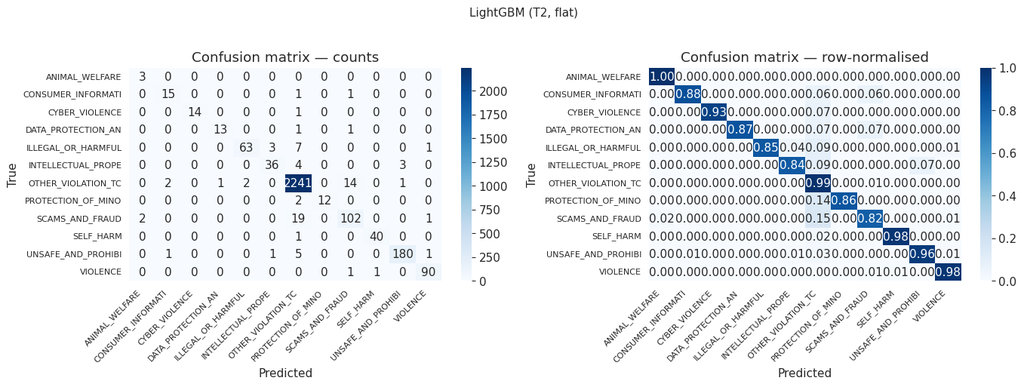

```python
# Confusion matrix — normalised and raw
fig, axes = plt.subplots(1, 2, figsize=(14, 5))
short = [l[:18] for l in target_labels]  # truncated labels for readability
for ax, norm in zip(axes, [None, "true"]):
    cm_arr = confusion_matrix(y_te, y_best_pred,
                              normalize=norm if norm else None)
    sns.heatmap(cm_arr, annot=True, fmt=("d" if norm is None else ".2f"),
                cmap="Blues", ax=ax, xticklabels=short, yticklabels=short)
    ax.set_xlabel("Predicted"); ax.set_ylabel("True")
    ax.set_title(f"Confusion matrix — {'counts' if norm is None else 'row-normalised'}")
    ax.set_xticklabels(ax.get_xticklabels(), rotation=45, ha="right", fontsize=8)
    ax.set_yticklabels(ax.get_yticklabels(), rotation=0, fontsize=8)
plt.suptitle(best_name, fontsize=11, y=1.02)
plt.tight_layout(); plt.show()
```

### TP-7.2 · Per-Class F1 Score

Visualise F1 for every category, colour-coded by performance tier: red < 0.3 (poor), amber < 0.6 (moderate), green ≥ 0.6 (good). Classes in red are the primary targets for further improvement (more samples, better text features, or class-specific thresholds).

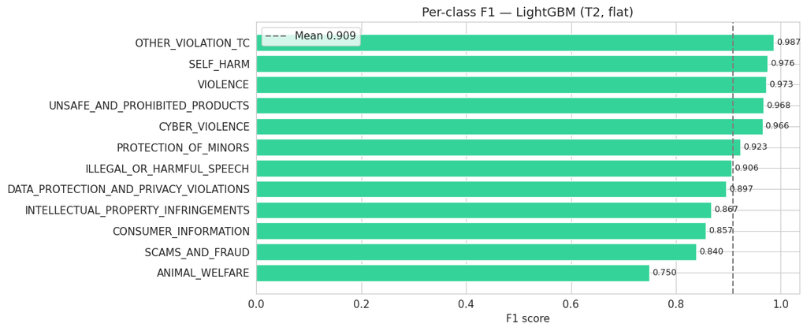

```python
# Per-class F1 — sorted ascending so the worst performers appear at the top
per_f1 = f1_score(y_te, y_best_pred, average=None, zero_division=0)
f1_s   = pd.Series(per_f1, index=target_labels).sort_values()
fig, ax = plt.subplots(figsize=(12, 5))
colors_f1 = ["#f87171" if v < 0.3 else "#fbbf24" if v < 0.6 else "#34d399" for v in f1_s.values]
ax.barh(f1_s.index, f1_s.values, color=colors_f1)
ax.axvline(f1_s.mean(), ls="--", color="grey", label=f"Mean {f1_s.mean():.3f}")
ax.set_xlabel("F1 score"); ax.set_title(f"Per-class F1 — {best_name}"); ax.legend()
for i, v in enumerate(f1_s.values):
    ax.text(v + 0.005, i, f"{v:.3f}", va="center", fontsize=9)
plt.tight_layout(); plt.show()
```

### TP-7.3 · Top Misclassification Pairs

List the 20 most frequent true→predicted misclassification pairs together with their count and percentage of the true class's test rows. These pairs reveal which category boundaries are most ambiguous and should be prioritised for manual label review or feature-engineering investment.

```python
# Top misclassification pairs
cm_mc = confusion_matrix(y_te, y_best_pred)
pairs = []
for i in range(n_classes):
    for j in range(n_classes):
        if i != j and cm_mc[i, j] > 0:
            pairs.append({"True": target_labels[i], "Predicted": target_labels[j],
                          "Count": int(cm_mc[i, j]),
                          "% of true": f"{100*cm_mc[i,j]/cm_mc[i].sum():.1f}%"})
err_df = pd.DataFrame(pairs).sort_values("Count", ascending=False).head(20)
print("Top 20 misclassification pairs:")
display(err_df)
```

```
Top 20 misclassification pairs:
```

|  | True | Predicted | Count | % of true |
| --- | --- | --- | --- | --- |
| 17 | SCAMS_AND_FRAUD | OTHER_VIOLATION_TC | 19 | 15.3% |
| 13 | OTHER_VIOLATION_TC | SCAMS_AND_FRAUD | 14 | 0.6% |
| 6 | ILLEGAL_OR_HARMFUL_SPEECH | OTHER_VIOLATION_TC | 7 | 9.5% |
| 22 | UNSAFE_AND_PROHIBITED_PRODUCTS | OTHER_VIOLATION_TC | 5 | 2.7% |
| 8 | INTELLECTUAL_PROPERTY_INFRINGEMENTS | OTHER_VIOLATION_TC | 4 | 9.3% |
| 5 | ILLEGAL_OR_HARMFUL_SPEECH | INTELLECTUAL_PROPERTY_INFRINGEMENTS | 3 | 4.1% |
| 9 | INTELLECTUAL_PROPERTY_INFRINGEMENTS | UNSAFE_AND_PROHIBITED_PRODUCTS | 3 | 7.0% |
| 12 | OTHER_VIOLATION_TC | ILLEGAL_OR_HARMFUL_SPEECH | 2 | 0.1% |
| 15 | PROTECTION_OF_MINORS | OTHER_VIOLATION_TC | 2 | 14.3% |
| 16 | SCAMS_AND_FRAUD | ANIMAL_WELFARE | 2 | 1.6% |
| 10 | OTHER_VIOLATION_TC | CONSUMER_INFORMATION | 2 | 0.1% |
| 2 | CYBER_VIOLENCE | OTHER_VIOLATION_TC | 1 | 6.7% |
| 7 | ILLEGAL_OR_HARMFUL_SPEECH | VIOLENCE | 1 | 1.4% |
| 4 | DATA_PROTECTION_AND_PRIVACY_VIOLATIONS | SCAMS_AND_FRAUD | 1 | 6.7% |
| 0 | CONSUMER_INFORMATION | OTHER_VIOLATION_TC | 1 | 5.9% |
| 1 | CONSUMER_INFORMATION | SCAMS_AND_FRAUD | 1 | 5.9% |
| 3 | DATA_PROTECTION_AND_PRIVACY_VIOLATIONS | OTHER_VIOLATION_TC | 1 | 6.7% |
| 11 | OTHER_VIOLATION_TC | DATA_PROTECTION_AND_PRIVACY_VIOLATIONS | 1 | 0.0% |
| 14 | OTHER_VIOLATION_TC | UNSAFE_AND_PROHIBITED_PRODUCTS | 1 | 0.0% |
| 18 | SCAMS_AND_FRAUD | VIOLENCE | 1 | 0.8% |

## TP-8 · Save Model Artifact & Upload to Hopsworks Model Registry

Serialise the best model pipeline, both preprocessors, label maps, column lists, and platform automation rates into a single pickle artifact (`category_best_model.pkl`). Then copy the artifact to the export directory and register it in the Hopsworks Model Registry so the Inference Pipeline can discover and download it by name/version.

```python
save_obj = {
    "name":          best_name,
    "tier":          best_tier,
    "macro_f1":      best_macro_f1,
    "target_labels": target_labels,
    "label_map":     label_map,
    "label_map_inv": label_map_inv,
    "other_label":   other_idx,
    "FEATURE_COLS":  FEATURE_COLS,
    "CATEGORICAL_FEATURES": CATEGORICAL_FEATURES,
    "NUMERICAL_FEATURES":   NUMERICAL_FEATURES,
    "TEXT_COL":      TEXT_COL,
    "TEXT_COL_2":    TEXT_COL_2,
    "TEXT_COL_3":    TEXT_COL_3,
    "preprocessor_t1": preprocessor_t1,
    "preprocessor_t2": preprocessor_t2,
    # Training-era per-platform automation rate so inference
    # applies the same values the model was trained on.
    "platform_automation_rates": PLATFORM_AUTOMATION_RATES,
}

if best_pipe is None:
    raise KeyError(f"best_name '{best_name}' not found in model_map — add it explicitly.")
save_obj["pipeline"] = best_pipe

# Write the artifact locally
with open(MODEL_ARTIFACT, "wb") as f:
    pickle.dump(save_obj, f)
print(f"Model artifact saved → {MODEL_ARTIFACT}  "
      f"({MODEL_ARTIFACT.stat().st_size / 1e6:.1f} MB)")

# Stage a copy for Hopsworks upload (registry expects a directory)
MODEL_EXPORT_DIR.mkdir(exist_ok=True)
shutil.copy(MODEL_ARTIFACT, MODEL_EXPORT_DIR / MODEL_ARTIFACT.name)

# Re-connect to Hopsworks and push to the Model Registry
project = hopsworks.login(
    host=HOPSWORKS_HOST,
    project=HOPSWORKS_PROJECT,
    api_key_value=HOPSWORKS_API_KEY,
)
mr = project.get_model_registry()

hops_model = mr.python.create_model(
    name=MODEL_NAME,
    metrics={"macro_f1": best_macro_f1, "balanced_accuracy": best_bal_acc},
    description=(
        f"Category classifier: {best_name}  |  Tier {best_tier}  "
        f"|  {n_classes} classes  |  macro F1={best_macro_f1:.4f}"
    ),
)
hops_model.save(str(MODEL_EXPORT_DIR))
print(f"Model uploaded to Hopsworks Model Registry: '{MODEL_NAME}'  "
      f"version={hops_model.version}")
```

```
Model artifact saved → category_best_model.pkl  (2.1 MB)
2026-05-20 08:48:07,476 INFO: Closing external client and cleaning up certificates.
2026-05-20 08:48:07,478 INFO: Connection closed.
2026-05-20 08:48:07,480 INFO: Initializing external client
2026-05-20 08:48:07,480 INFO: Base URL: https://eu-west.cloud.hopsworks.ai:443
```

```
2026-05-20 08:48:08,528 INFO: Python Engine initialized.

Logged in to project, explore it here https://eu-west.cloud.hopsworks.ai:443/p/32025
```

```
Moving model files from 'category_model_export' to the model registry... This is the default behavior. Set keep_original_files=True to copy files instead.
```

[output not shown]

```
Model created, explore it at https://eu-west.cloud.hopsworks.ai:443/p/32025/models/category_classifier/1
Model uploaded to Hopsworks Model Registry: 'category_classifier'  version=1
```

## TP-9 · Summary

Auto-generate a markdown report summarising the training run: timestamp, train/test split sizes, best model name, tier, macro F1, balanced accuracy, and a table of all evaluated models. This cell can be copied directly into experiment-tracking tickets or documentation.

```python
lines = [
    "## Task A — Category Classification Results",
    "",
    f"**Generated:** {datetime.now().strftime('%Y-%m-%d %H:%M')}  ",
    f"**Train/Test:** {len(X_tr):,} / {len(X_te):,}  "
    f"|  **Primary metric:** macro F1  ",
    "",
    "### Best model",
    "| | |", "|---|---|",
    f"| Model | {best_name} |",
    f"| Tier  | {best_tier} |",
    f"| Macro F1 | {best_macro_f1:.4f} |",
    f"| Balanced accuracy | {best_bal_acc:.4f} |",
    f"| Dummy baseline macro F1 | {results['Dummy (most_frequent)']['macro_f1']:.4f} |",
    "",
    "### All results",
    "| Model | Tier | Approach | Macro F1 | Balanced Acc |",
    "|---|---|---|---|---|",
]
# Append one markdown table row per model, sorted by macro F1 descending
for _, row in df_all.iterrows():
    lines.append(f"| {row['model']} | {row['tier']} | {row['approach']} "
                 f"| {float(row['macro_f1']):.4f} | {float(row['bal_acc']):.4f} |")

display(Markdown("\n".join(lines)))
```

Task A — Category Classification Results

**Generated:** 2026-05-20 08:48  
**Train/Test:** 11,545 / 2,887 | **Primary metric:** macro F1

Best model

| Model | LightGBM (T2, flat) |
| --- | --- |
| Tier | 2 |
| Macro F1 | 0.9091 |
| Balanced accuracy | 0.9128 |
| Dummy baseline macro F1 | 0.0732 |

All results

| Model | Tier | Approach | Macro F1 | Balanced Acc |
| --- | --- | --- | --- | --- |
| LightGBM (T2, flat) | 2 | flat | 0.9091 | 0.9128 |
| LightGBM (T2, two-stage) | 2 | two-stage | 0.8998 | 0.9010 |
| LightGBM (T1, flat) | 1 | flat | 0.5864 | 0.5784 |
| LightGBM (T1, two-stage) | 1 | two-stage | 0.5817 | 0.5678 |
| LogisticRegression (T1, flat) | 1 | flat | 0.3062 | 0.5461 |
| Dummy (most_frequent) | 0 | baseline | 0.0732 | 0.0833 |